# 2_Linearfaktordarstellung slides

## 2. Linearfaktordarstellung

**Beispiel:** $$ f(x)= \frac{1}{2}(x-1)(x+2)(x+3)\qquad \qquad g(x)= \frac{1}{2}x^3+2x^2+\frac{x}{2}-3 $$

|  | f(x) | g(x) |
| --- | --- | --- |
| Grad | auszurechenen | ablesbar |
|  |  | $$ \text{grad}(f)=3$$ |
| Nullstellen | ablesbar | auszurechnen |
|  | $$ \begin{align*}n_1&=-3\\n_2&=-2\\n_3&=1 \end{align*}$$ |  |
| Aufbau | Produkt von Linearfaktoren | Polynom |

**Definition:**

Bestehen Faktoren einer Multiplikation aus linearen Elementen der Form $ax+b, \quad a,b \in \mathbb{R}$, so bezeichnet man die Faktoren als Linearfaktoren.

Schauen wir uns die Funktionsgraphen der Fuktion f und g an:

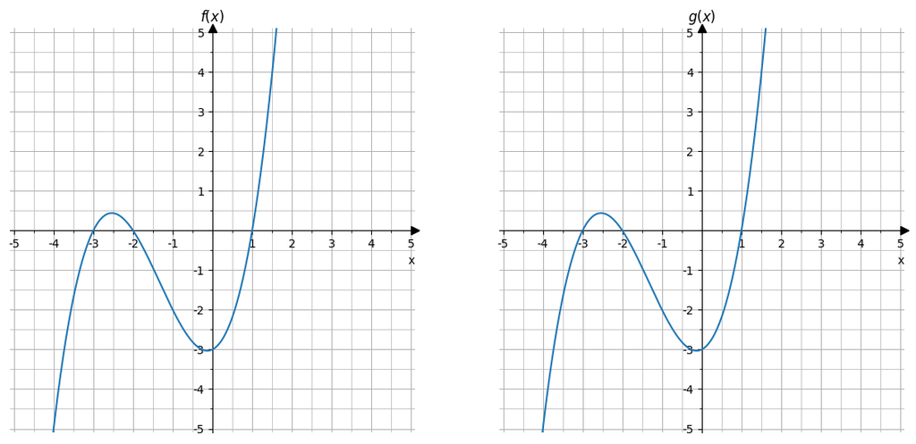

**Satz 1:**

a Jede ganzrationale Funktion in Lienarfaktordarstellung lässt sich durch ausmultiplizieren in eine Polynomfunktion umformen.  
b Nicht jede ganzrationale Funktion besitzt eine Liearfaktordarstellung.

**Beweis:**

a klar $ $  
b Gegenbeispiel: $f(x)=x^2+1$

**Satz 2:**

Ist eine ganzrationale Funktion f vom Grad n und der Nullstelle c gegeben, so gibt es eine ganzrationale Funktion g vom Grad n-1, so dass gilt: $$f(x)=(x-c)\cdot g(x)$$

**Beweis:**

Gegeben:

- ganzrationale Funktion f
- $\text{grad}(f)=n$
- c Nullstelle von f

Verschiebung der Nullstelle c in den Ursprung durch Verschieben des Graphen von f entlang der x-Achse um $-c$ erzeugt eine neue Funktion h: $$ h(x)=f(x-(-c))=f(x+c) $$ Eigenschaften von h:

- h ist auch eine ganzrationale Funktion mit $h(x)=a_nx^n + a_{n-1}x^{n-1} + ...+a_0$
- $x_0=0$ ist eine Nullstelle von h, d.h. $h(0)= f(0+c)=f(c)=0$

Es folgt damit: $a_0=0$

und es gilt:

$$ \begin{align*} h(x) &= a_nx^n + a_{n-1}x^{n-1} + ... +a_1x \\ &= x\cdot \left (a_n x^{n-1}+ a_{n-1}x^{n-2}+ ... + a_1\right)\\ &= x \cdot k(x) \end{align*} $$

Eigneschaften von k(x):

- ganzrationale Funktion
- Gleichung $k(x)=a_n x^{n-1}+ a_{n-1}x^{n-2}+ ... + a_1$
- $\text{grad}(k)=n-1 $

Zurückverschiebung des Graphen von h um c entlang der x-Achse ergibt den Graphen von f und es gilt: $$ \begin{align*} f(x)&= h(x-c)\\ &= (x-c)\cdot k(x-c)\\ &= (x-c) \cdot g(x), \quad \text{mit } g(x)=k(x-c) \end{align*} $$ mit $\text{grad}(g) = \text{grad}(k) = n-1 \square$

**Satz 3:**

Eine ganzrationale Funktion f vom Grad n hat höchstens n Nullstellen.

**Beweis:**

Gegeben:$$f(x)=a_nx^n+a_{n-1}x^{n-1}+...+a_1x+a_0$$ mit $\text{grad}(f)=n$

$\Rightarrow$ Es gibt ein $c_1$, so das gilt: $$\begin{align*}f(x) &= (x-c_1)\cdot \left( a_{n-1}x^{n-1}+...+a_1x+a_0\right)\\ &= (x-c_1)\cdot g(x) \end{align*}$$

$\Rightarrow \quad \text{grad}(g)=\text{grad}(f)-1 = n-1$

Sei $c_2$ weiter Nullstelle von f(x).
$\Rightarrow$ $$ \begin{align*}f(x)&=(x-c_1)(x-c_2)\left( a_{n-2}x^{n-2}+...+a_1x+a_0\right)\\ &= (x-c_1)(x-c_2)\cdot h(x) \end{align*}$$ $\Rightarrow \quad \text{grad}(h)=\text{grad}(f)-2 = n-2$

Die Durchführung dieser Schritte ist insgesamt maximal n-mal möglich. $\square$